# Predict Probability of Sales on Inbound Call Center Traffic

## Project description

This project aims at predicting the sale on next call based on caller’s demographic, socio economic data, location and the source of traffic (paid, SEO or affiliate). A sale comprises sale of any combination of cable, internet or phone service to a residential caller in any part of US depending on the availability of service at the caller’s address. Call center sales agents have access to order entry tool for almost all the major cable, internet and phone service providers in the country which enables them to sell any provider the caller is looking for.

Ordering cable, internet and phone services is a complex process that requires customization and selection of many features on callers part and also because the price a customer pays on a monthly basis, varies with the choice of channels selection for a cable product, speed of internet package and in case of phone whether in-state or out-of-state calling is selected or not. People usually need assistance in order to order services and hence call in.

Before calling, callers generally search online to get an idea of what they should order and who to reach out to in order to get services. The search is mostly carried out on some of the popular search engines such as google, bing, yahoo etc. This particular call center markets its services on these search engines to generate demand and to drive calls to the center.

Data Source: In order to predict the sales outcome on a call, calls data for May 2016 has been used. Over 440K calls were offered in the call center in May of which about 400K calls got answered. The data is contained in an excel sheet. A summary of variables is obtained by running the summary() command on the read data.

```
## [1] "C/C/C/C/C/en_US.UTF-8"
```

```
##    CallDate         CallStartTime      CallEndTime
##  Length:409555      Length:409555      Length:409555
##  Class :character   Class :character   Class :character
##  Mode  :character   Mode  :character   Mode  :character
##
##
##
##    Outcome            AgentID               TFN
##  Length:409555      Length:409555      Min.   :2.153e+09
##  Class :character   Class :character   1st Qu.:8.444e+09
##  Mode  :character   Mode  :character   Median :8.552e+09
##                                        Mean   :8.016e+09
##                                        3rd Qu.:8.558e+09
##                                        Max.   :8.889e+09
##      BTN              CallSkill     OriginalSkill   CableCompany
##  Length:409555      Min.   :100.0   Min.   :  0.0   Length:409555
##  Class :character   1st Qu.:300.0   1st Qu.:301.0   Class :character
##  Mode  :character   Median :302.0   Median :302.0   Mode  :character
##                     Mean   :274.4   Mean   :310.4
##                     3rd Qu.:310.0   3rd Qu.:308.0
##                     Max.   :999.0   Max.   :999.0
##   Affiliate         Disposition
##  Length:409555      Length:409555
##  Class :character   Class :character
##  Mode  :character   Mode  :character
##
##
##
```

A brief description of the variables in the data set is as follows:

1. Call.Date : Captures the day of month when the call arrived. The dataset has calls answered for all 31 days in May.
2. CallStartTime: Time when call started
3. CallEndTime: Time when call ended
4. Outcome: This captures whether a call got successfully connected to an agent or not. For this analysis, all connected calls have been taken. This variable does not have any preditive capability and will be dropped.
5. AgentID: Every agent in the center is assigned a unique ID captured by AgentID field.
6. TFN : The toll free name dialled by the customer to reach us to order services
7. BTN : Phone number of the customer
8. CallSkill : Agents are divided into various skill in the call center. A skill comprises a group of agents who are expert in selling a particular group of services. Some agents are multiskilled. CallSkill is the skill of the agent who answered the call.
9. OrigianlSkill: In case all agents on a skill are busy, the call is answered by the next available agent on another skill. The agent who was originally supposed to answer the call is captured by OriginalSkill variable.
10. CableCompany: THere are 24 skills in the center.
11. Affiliate: In addition to generating demand by marketing on search engines, some third party parnters also send traffic to the call center. They use a mix of marketing channels to drive traffic. The name of an affiliate is captured by this variable. The call center’s own sources of traffic are grouped under “Digital Globe Services” to differentiate from the rest.
12. Disposition: At the end of a call the call center agent classifies a call as sales/non-sales calls captured by the disposition variable. To better understand what happened on a call, disposition field helps capture the caller intent. A sale could be a sale of one service (A single play sale), two services (a double play sale), three services (a triple play sale), or four services (a quad play). The revenue generated on a call depends on the number of services sold.

## Data Cleaning

The disposition of the call depends on a number of factors such as the area the caller was calling from, the affiliate that drove the call, call skill and the TFN. A more detailed explanation of each varilable and cleaning the data is presented below. 1. TFN

```
## [1] 5417
```

2. BTN : The BTN field should ideally have customer phone number and be 10 digits long. However, there are many BTNs which have more than 10 digits. There is a leading 1 in most of these TFNs which need to be removed. Also, some BTNs have more than 1 call answered which shows that these are numbers some of the affiliates using to send traffic. These BTNs need to be removed. After removing the calls with 2 or more BTNs, we are left with roughly 325,000 calls.

```
## [1] 326704
```

```
##    CallDate CallStartTime CallEndTime Outcome AgentID        TFN
## 1 5/31/2016   11:10:23 AM 11:13:49 AM CONNECT    8522 8445953184
##          BTN CallSkill OriginalSkill CableCompany              Affiliate
## 1 8473443998       101           301      COMCAST Digital Globe Services
##                            Disposition AreaCode
## 1 Not interested - CS unable to upsell      847
```

```
##    AgentID             CallsAns
##  Length:689         Min.   :   1.0
##  Class :character   1st Qu.: 131.0
##  Mode  :character   Median : 491.0
##                     Mean   : 474.2
##                     3rd Qu.: 756.0
##                     Max.   :1326.0
```

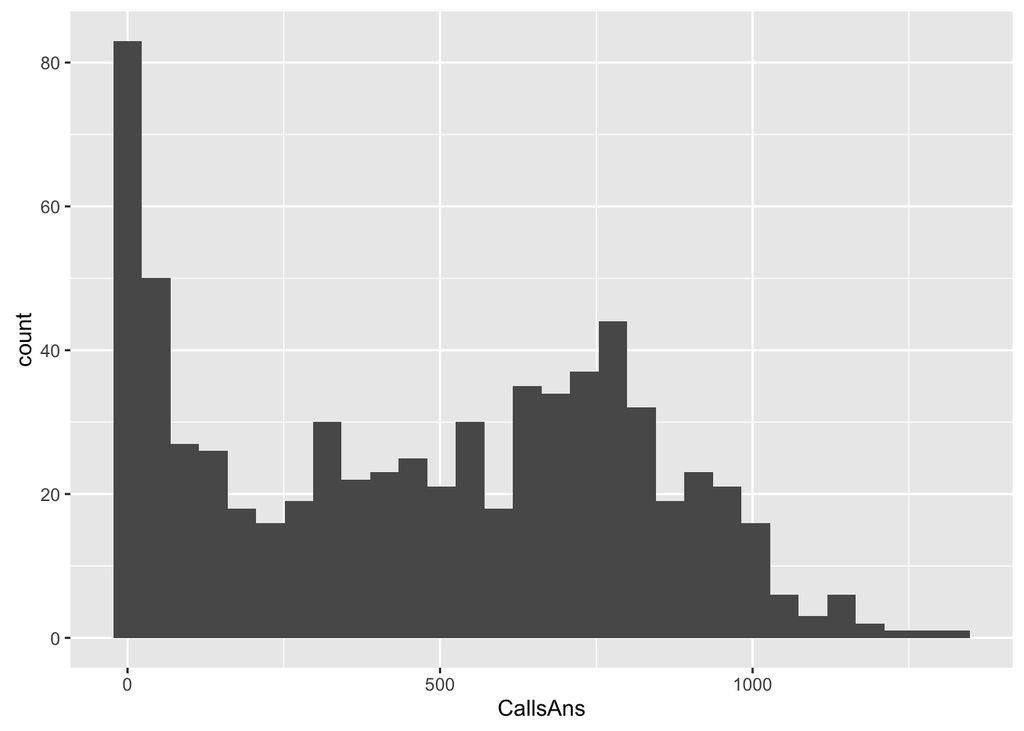

The CableCompany field shows 345 cable companies. However, there are many comapnies which have fewer than 10 calls in the whole month. A distribution of the calls answered by CableCompany is shown below. Some Cable Company names need to be cleaned such as converting lower to upper case etc. After cleaning up, the number of Cable Company reduces to 323.

```
## [1] 345
```

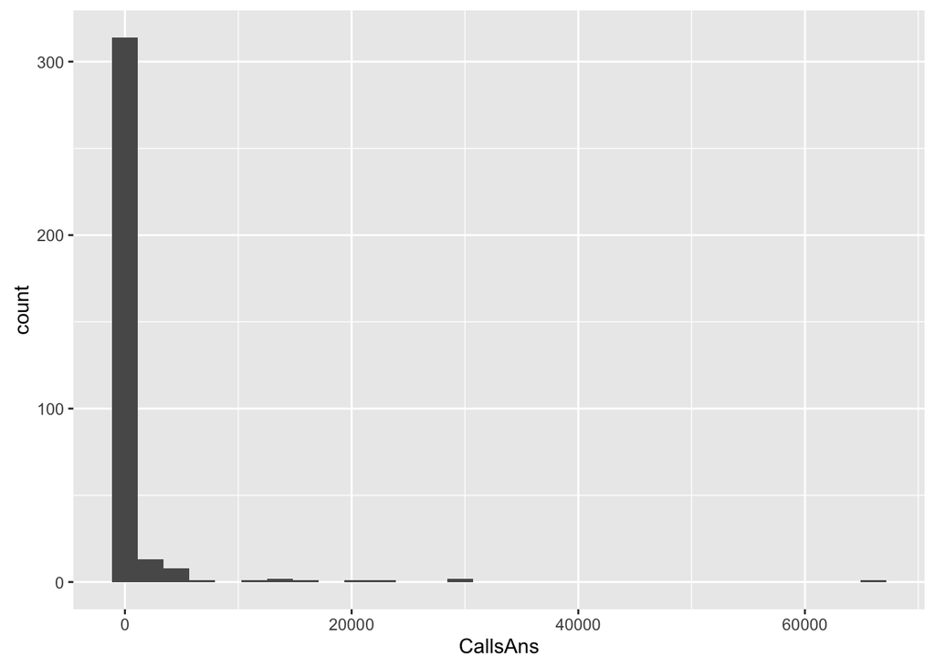

```
##    Min. 1st Qu.  Median    Mean 3rd Qu.    Max.
##       1       4      14     947     181   66030
```

```
## [1] 89
```

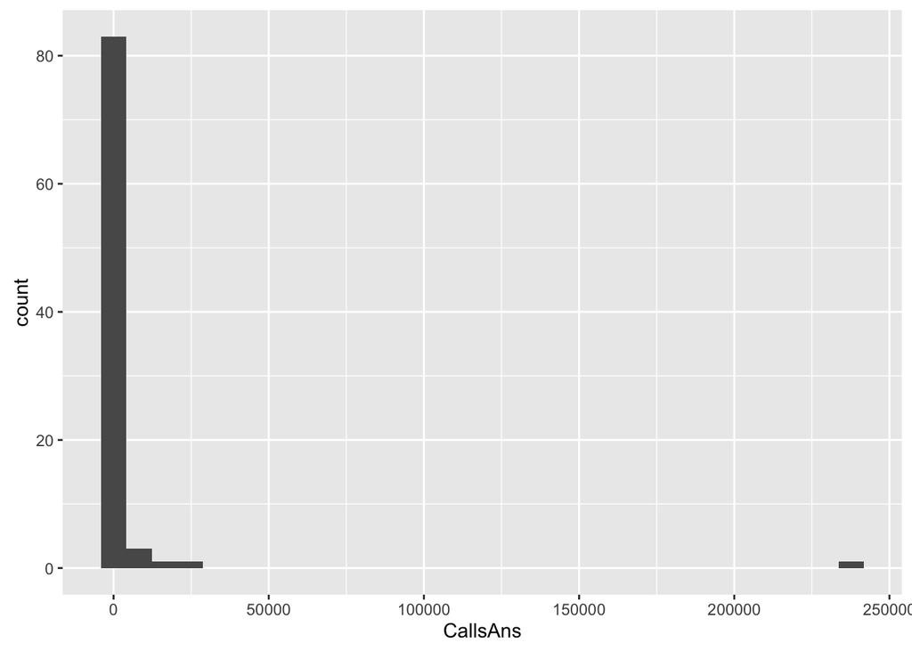

Disposition fields captures the end of call status whether it was a sale or otherwise. Since we are trying to predict whether a call will result in a sale or not and the associated probabilities, the disposition variable to reduced to a sale/no sale variable. 93% of all calls did not result in a sales while sales close rate is roughly 7%.

```
##
##   No Sale      Sale
## 93.114869  6.885131
```

```
##
## No Sale    Sale
##  93.115   6.885
```

```
## [1] "Total number of variables is: 9"
```

```
## [1] "Number of days :  31"
```

```
## [1] "Unique Agents :  689"
```

```
## [1] "Unique TFNs :  5255"
```

```
## [1] "No of area codes :  404"
```

```
## [1] "No of CallSkills :  24"
```

```
## [1] "No of Original Skills :  17"
```

```
## [1] "No of CableCompany :  323"
```

```
## [1] "No of Affiliates :  89"
```

```
## [1] "Percent of CallsDate, Pr(CallsDate)"
```

```
## # A tibble: 31 x 2
##     CallDate PercentOfTot
##        <chr>        <dbl>
## 1   5/1/2016         2.07
## 2  5/10/2016         3.92
## 3  5/11/2016         3.77
## 4  5/12/2016         3.47
## 5  5/13/2016         3.51
## 6  5/14/2016         2.37
## 7  5/15/2016         1.74
## 8  5/16/2016         4.16
## 9  5/17/2016         3.76
## 10 5/18/2016         3.59
## # ... with 21 more rows
```

```
## [1] "Percent of AgentId, Pr(AgentID)"
```

```
## # A tibble: 689 x 2
##    AgentID PercentOfTot
##      <chr>        <dbl>
## 1     5550       0.0383
## 2     5566       0.0006
## 3     5600       0.0018
## 4     5627       0.0606
## 5     5641       0.0046
## 6     5658       0.0028
## 7     5675       0.3318
## 8     5695       0.0187
## 9     5704       0.0009
## 10    5707       0.0122
## # ... with 679 more rows
```

```
## [1] "Percent of TFN, Pr(TFN)"
```

```
## # A tibble: 5,255 x 2
##           TFN PercentOfTot
##         <dbl>        <dbl>
## 1  2153373582       0.0092
## 2  2153373587       0.0009
## 3  2153373636       0.0024
## 4  2153373637       0.0006
## 5  2153373640       0.1004
## 6  2153373641       0.0897
## 7  2153373642       0.0040
## 8  2153373643       0.0018
## 9  2153373644       0.0049
## 10 2153373645       0.0046
## # ... with 5,245 more rows
```

```
## [1] "Percent of CallSkill, Pr(CallSkill)"
```

```
## # A tibble: 24 x 2
##    CallSkill PercentOfTot
##        <int>        <dbl>
## 1        100       2.9645
## 2        101       5.1778
## 3        102       4.7009
## 4        103       3.5607
## 5        108       1.8524
## 6        117       0.7233
## 7        210       0.9489
## 8        222       1.8687
## 9        300       6.4606
## 10       301      18.8795
## # ... with 14 more rows
```

```
## [1] "Percent of OrigSkill, Pr(OrigSkill)"
```

```
## # A tibble: 17 x 2
##    OriginalSkill PercentOfTot
##            <int>        <dbl>
## 1              0       0.0236
## 2            222       2.8151
## 3            300       9.4250
## 4            301      31.6819
## 5            302      18.0824
## 6            303      14.2591
## 7            308       8.5346
## 8            310       0.0355
## 9            313       1.6235
## 10           315       0.4062
## 11           317       5.3421
## 12           328       2.5463
## 13           350       1.5240
## 14           500       2.7520
## 15           501       0.6804
## 16           513       0.2345
## 17           999       0.0337
```

```
## [1] "Percent of CableCompany, Pr(CableCompany)"
```

```
## # A tibble: 323 x 2
##                                CableCompany PercentOfTot
##                                       <chr>        <dbl>
## 1                                                 0.0658
## 2                                10Channels       0.0003
## 3                      2TurnItOn - Outbound       0.0533
## 4                                     5LINX       0.0312
## 5                732 Numbers Charter Retail       0.0028
## 6                      732Numbers Earthlink       0.0569
## 7  76766 -\240nuHome Promotions - MSO - TWC       0.0104
## 8     80191 - nuHome Promotions - MSO - COX       0.0101
## 9                                       ADT       0.0070
## 10                                      AOL       0.0003
## # ... with 313 more rows
```

```
## [1] "Percent of Affiliate, Pr(Affiliate)"
```

```
## # A tibble: 89 x 2
##                   Affiliate PercentOfTot
##                       <chr>        <dbl>
## 1                10Channels       0.0003
## 2             2TurnItOn.com       0.0533
## 3                     5LINX       0.0312
## 4           732-Numbers LLC       0.1457
## 5                   ABENITY       0.0006
## 6            AP Media Group       0.0003
## 7              Acceller_DSI       0.0591
## 8               Adknowledge       0.0018
## 9  Advanced Home Protection       0.1491
## 10          All Bundles LLC       0.0003
## # ... with 79 more rows
```

```
## [1] "Percent of AreaCode, Pr(AreaCode)"
```

```
## # A tibble: 404 x 2
##    AreaCode PercentOfTot
##       <chr>        <dbl>
## 1       201       0.3168
## 2       202       0.5993
## 3       203       0.5803
## 4       204       0.0037
## 5       205       0.4637
## 6       206       0.3128
## 7       207       0.3750
## 8       208       0.2479
## 9       209       0.4028
## 10      210       0.6657
## # ... with 394 more rows
```

```
## [1] "Percent of Sale , Pr(C)"
```

```
## # A tibble: 2 x 2
##      Sale PercentOfTot
##     <chr>        <dbl>
## 1 No Sale        93.11
## 2    Sale         6.89
```

Probability of each factor level given conversation rate C

```
## [1] "Pr (CallDate | C)"
```

```
## Source: local data frame [31 x 2]
## Groups: CallDate [31]
##
##     CallDate SalesRate
##        <chr>     <dbl>
## 1   5/1/2016      5.25
## 2  5/10/2016      7.38
## 3  5/11/2016      7.11
## 4  5/12/2016      6.76
## 5  5/13/2016      6.73
## 6  5/14/2016      5.06
## 7  5/15/2016      5.13
## 8  5/16/2016      8.23
## 9  5/17/2016      7.56
## 10 5/18/2016      7.37
## # ... with 21 more rows
```

```
## [1] "Pr (AgentID | C)"
```

```
## Source: local data frame [620 x 2]
## Groups: AgentID [620]
##
##    AgentID SalesRate
##      <chr>     <dbl>
## 1     5550      3.20
## 2     5627      7.58
## 3     5641      6.67
## 4     5658     11.11
## 5     5675      7.10
## 6     5695      4.92
## 7     5707     17.50
## 8     5710     13.66
## 9     5860      2.86
## 10    5861      6.11
## # ... with 610 more rows
```

```
## [1] "Pr (TFN | C)"
```

```
## Source: local data frame [1,441 x 2]
## Groups: TFN [1,441]
##
##           TFN SalesRate
##         <dbl>     <dbl>
## 1  2153373582      3.33
## 2  2153373587     66.67
## 3  2153373640      6.40
## 4  2153373641      8.19
## 5  2153373642      7.69
## 6  2153373643     33.33
## 7  2153373644     18.75
## 8  2153373645      6.67
## 9  2153373646     14.71
## 10 2153373648     20.00
## # ... with 1,431 more rows
```

```
## [1] "Pr (CallSkill | C)"
```

```
## Source: local data frame [23 x 2]
## Groups: CallSkill [23]
##
##    CallSkill SalesRate
##        <int>     <dbl>
## 1        100      9.62
## 2        101      4.43
## 3        102      6.35
## 4        103      7.56
## 5        108      5.63
## 6        117      8.00
## 7        210      7.71
## 8        222      8.98
## 9        300     12.15
## 10       301      5.50
## # ... with 13 more rows
```

```
## [1] "Pr (OrigSkill | C)"
```

```
## Source: local data frame [16 x 2]
## Groups: OriginalSkill [16]
##
##    OriginalSkill SalesRate
##            <int>     <dbl>
## 1              0     12.99
## 2            222      8.56
## 3            300     11.36
## 4            301      4.88
## 5            302      6.61
## 6            303      7.28
## 7            308      6.71
## 8            310      4.31
## 9            313      5.45
## 10           315      0.08
## 11           317      8.20
## 12           328     12.97
## 13           350      7.21
## 14           500      6.77
## 15           501      8.19
## 16           513      2.87
```

```
## [1] "Pr (CableCompany | C)"
```

```
## Source: local data frame [153 x 2]
## Groups: CableCompany [153]
##
##                                CableCompany SalesRate
##                                       <chr>     <dbl>
## 1                                                6.98
## 2                      2TurnItOn - Outbound      1.72
## 3                                     5LINX     17.65
## 4                732 Numbers Charter Retail     11.11
## 5                      732Numbers Earthlink      1.61
## 6  76766 -\240nuHome Promotions - MSO - TWC     20.59
## 7     80191 - nuHome Promotions - MSO - COX     18.18
## 8                                       ATT      9.54
## 9                               ATT Spanish      5.43
## 10               ATT-Touchtone Technologies      2.26
## # ... with 143 more rows
```

```
## [1] "Pr (Affiliate | C)"
```

```
## Source: local data frame [43 x 2]
## Groups: Affiliate [43]
##
##                                        Affiliate SalesRate
##                                            <chr>     <dbl>
## 1                                  2TurnItOn.com      1.72
## 2                                          5LINX     17.65
## 3                                732-Numbers LLC      2.10
## 4                       Advanced Home Protection     18.28
## 5                          Broadband Corporation      4.55
## 6  CJ Communications dba Home Service Connection     16.11
## 7                                      CLEARLINK     14.70
## 8                                 CM Enterprises      9.40
## 9                           Cannon Satellite LLC     19.76
## 10                             Connect Your Home     14.04
## # ... with 33 more rows
```

```
## [1] "Pr (AreaCode | C)"
```

```
## Source: local data frame [304 x 2]
## Groups: AreaCode [304]
##
##    AreaCode SalesRate
##       <chr>     <dbl>
## 1       201      5.89
## 2       202      5.87
## 3       203      6.01
## 4       205      7.99
## 5       206      5.58
## 6       207      7.84
## 7       208     12.72
## 8       209      6.23
## 9       210      5.52
## 10      212      3.03
## # ... with 294 more rows
```

Calculate Bayesian probability for a specific call

Function to predict probability of sale in real time